# Alberto Doncel Pedrosa

### Práctica Final Series Temporales

### Instalación Inicial, Librerías y Carga de Datos

```python
! pip install sktime
! pip install pyod
! pip install iteration_utilities
! pip install pmdarima
```

[output not shown]

[output not shown]

```python
# Tratamiento de datos
# ==============================================================================
import numpy as np
import pandas as pd
from iteration_utilities import duplicates

# Gráficos
# ==============================================================================
import matplotlib.pyplot as plt
import seaborn as sns
%matplotlib inline
from statsmodels.graphics.tsaplots import plot_acf
from statsmodels.graphics.tsaplots import plot_pacf
plt.style.use('seaborn')

# Tratamiento de outliers
# ==============================================================================
from pyod.models.knn import KNN

# Configuración warnings
# ==============================================================================
import warnings
warnings.filterwarnings('once')


# Sktime fucntions
# ==============================================================================
from sktime.forecasting.base import ForecastingHorizon
from sktime.forecasting.model_selection import temporal_train_test_split
from sktime.transformations.series.boxcox import LogTransformer
from sktime.utils.plotting import plot_series
from sktime.forecasting.arima import AutoARIMA

from statsmodels.tsa.arima_model import ARIMA
import pmdarima as pm
from pmdarima.arima import auto_arima
```

```python
# Carga de datos
# ==============================================================================

df = pd.read_excel('DemandaEnergia.xlsx')
df.info()
```

```
<class 'pandas.core.frame.DataFrame'>
RangeIndex: 56272 entries, 0 to 56271
Data columns (total 7 columns):
 #   Column      Non-Null Count  Dtype
---  ------      --------------  -----
 0   Region      56272 non-null  object
 1   UTC time    56272 non-null  datetime64[ns]
 2   Local date  56272 non-null  datetime64[ns]
 3   Local hour  56272 non-null  int64
 4   Local time  56272 non-null  datetime64[ns]
 5   Time zone   56272 non-null  object
 6   D           56272 non-null  int64
dtypes: datetime64[ns](3), int64(2), object(2)
memory usage: 3.0+ MB
```

```python
df
```

|  | Region | UTC time | Local date | Local hour | Local time | Time zone | D |
| --- | --- | --- | --- | --- | --- | --- | --- |
| 0 | CAL | 2015-07-01 08:00:00 | 2015-07-01 | 1 | 2015-07-01 01:00:00 | Pacific | 38210 |
| 1 | CAL | 2015-07-01 09:00:00 | 2015-07-01 | 2 | 2015-07-01 02:00:00 | Pacific | 35171 |
| 2 | CAL | 2015-07-01 10:00:00 | 2015-07-01 | 3 | 2015-07-01 03:00:00 | Pacific | 33243 |
| 3 | CAL | 2015-07-01 11:00:00 | 2015-07-01 | 4 | 2015-07-01 04:00:00 | Pacific | 31955 |
| 4 | CAL | 2015-07-01 12:00:00 | 2015-07-01 | 5 | 2015-07-01 05:00:00 | Pacific | 31199 |
| ... | ... | ... | ... | ... | ... | ... | ... |
| 56267 | CAL | 2021-11-30 19:00:00 | 2021-11-30 | 11 | 2021-11-30 11:00:00 | Pacific | 29068 |
| 56268 | CAL | 2021-11-30 20:00:00 | 2021-11-30 | 12 | 2021-11-30 12:00:00 | Pacific | 28769 |
| 56269 | CAL | 2021-11-30 21:00:00 | 2021-11-30 | 13 | 2021-11-30 13:00:00 | Pacific | 29180 |
| 56270 | CAL | 2021-11-30 22:00:00 | 2021-11-30 | 14 | 2021-11-30 14:00:00 | Pacific | 29719 |
| 56271 | CAL | 2021-11-30 23:00:00 | 2021-11-30 | 15 | 2021-11-30 15:00:00 | Pacific | 30512 |

56272 rows × 7 columns

```python
df_selected_LOCAL = df.set_index('Local time')
```

```python
#Función para determinar si el índice está repetido

def listRep(ListFecha):
  return list(duplicates(ListFecha))

ListFecha = list(df_selected_LOCAL.index)
list(df_selected_LOCAL.index)

listRep(ListFecha)
```

```
[Timestamp('2015-11-01 01:00:00'),
 Timestamp('2016-11-06 01:00:00'),
 Timestamp('2017-11-05 01:00:00'),
 Timestamp('2018-11-04 01:00:00'),
 Timestamp('2019-11-03 01:00:00'),
 Timestamp('2020-11-01 01:00:00'),
 Timestamp('2021-11-07 01:00:00')]
```

```python
df = df.drop_duplicates()
```

```python
df.isnull().sum()
```

```
Region        0
UTC time      0
Local date    0
Local hour    0
Local time    0
Time zone     0
D             0
dtype: int64
```

```python
df.isna().sum()
```

```
Region        0
UTC time      0
Local date    0
Local hour    0
Local time    0
Time zone     0
D             0
dtype: int64
```

```python
df_selected_UTC = df.set_index('UTC time')
```

```python
ListFecha = list(df_selected_UTC.index)
list(df_selected_UTC.index)

listRep(ListFecha)
```

```
[]
```

### EDA

```python
df_selected_LOCAL = df_selected_LOCAL.drop(['Region','UTC time', 'Time zone', 'Local date', 'Local hour'], axis = 1)
```

```python
df_selected_LOCAL
```

| Local time | D |
| --- | --- |
| 2015-07-01 01:00:00 | 38210 |
| 2015-07-01 02:00:00 | 35171 |
| 2015-07-01 03:00:00 | 33243 |
| 2015-07-01 04:00:00 | 31955 |
| 2015-07-01 05:00:00 | 31199 |
| ... | ... |
| 2021-11-30 11:00:00 | 29068 |
| 2021-11-30 12:00:00 | 28769 |
| 2021-11-30 13:00:00 | 29180 |
| 2021-11-30 14:00:00 | 29719 |
| 2021-11-30 15:00:00 | 30512 |

56272 rows × 1 columns

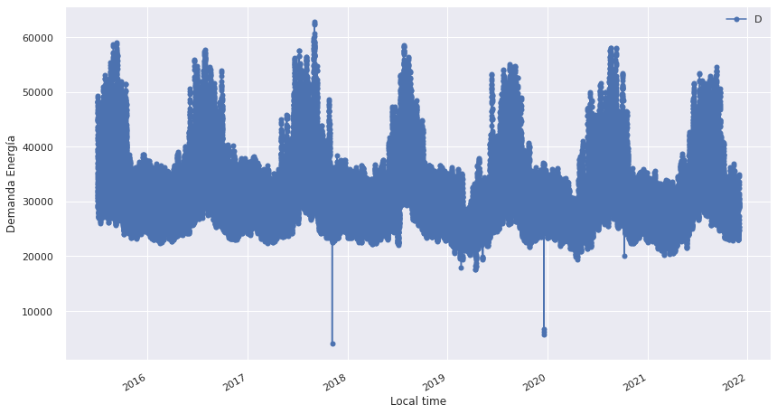

```python
# Graficamos para primera prospección
sns.set(rc={'figure.figsize':(14, 8)})
ax = df_selected_LOCAL.plot(marker='o', linestyle='-')
ax.set_ylabel('Demanda Energía');
```

Observamos que existen outliers que pueden comprometer la predicción, lo que hará necesario su procesamiento. En este caso, la estrategia puede ser realizar un modelo de intervención y realizar las predicciones o bien, tratar los outliers previamente para operar con los datos.

De la misma forma se van a crear dos datasets para operar a nivel de periodicidad horaria y a nivel de periodicidad diaria.

```python
df_selected_LOCAL['Año'] = df_selected_LOCAL.index.year
df_selected_LOCAL['Mes'] = df_selected_LOCAL.index.month
df_selected_LOCAL['Dia'] = df_selected_LOCAL.index.weekday
df_selected_LOCAL_d = df_selected_LOCAL.resample("d").sum()
df_selected_LOCAL_h = df_selected_LOCAL.resample("h").sum()
df_selected_LOCAL_h['Hora'] = df_selected_LOCAL_h.index.hour
```

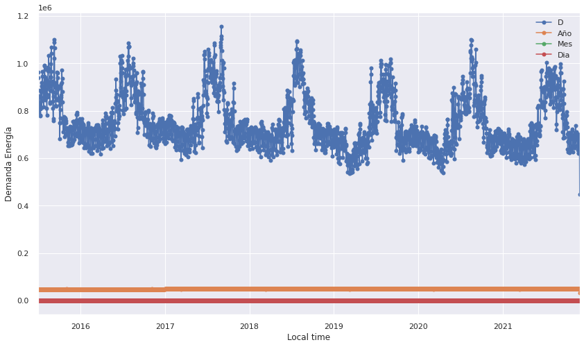

```python
sns.set(rc={'figure.figsize':(14, 8)})
ax = df_selected_LOCAL_d.plot(marker='o', linestyle='-')
ax.set_ylabel('Demanda Energía');
```

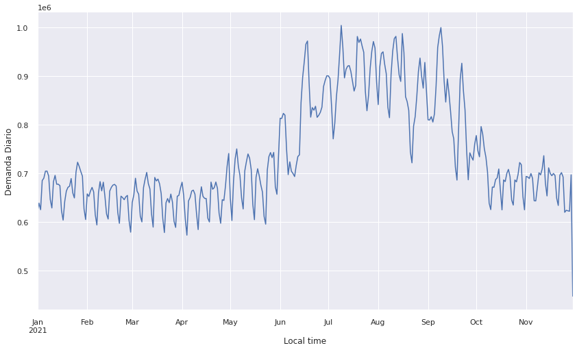

```python
eje = df_selected_LOCAL_d.loc['2021','D'].plot()
eje.set_ylabel('Demanda Diario')
```

#### Estacionalidad

Aunque existe tendencia anual, concentrada en los meses de verano, el uso de los meses previos a la variable objetivo como elementos de predicción no se va a haber afectado por dicha estacionalidad.

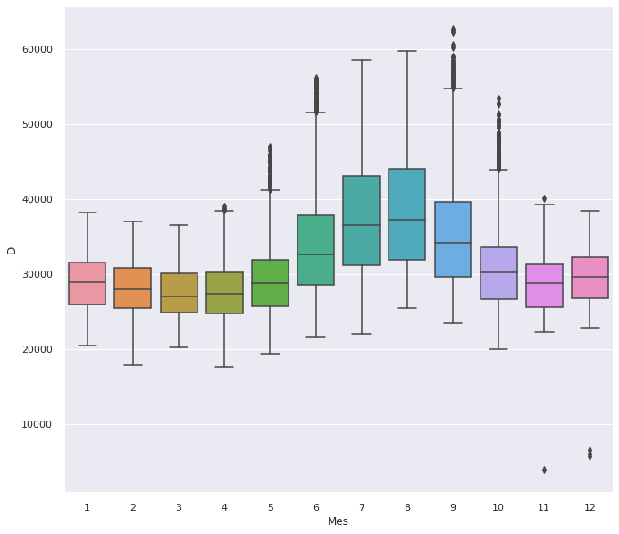

```python
fig, ejes = plt.subplots(1, 1, figsize=(11, 10), sharex=True)
sns.boxplot(data=df_selected_LOCAL,x= 'Mes', y= "D")
eje.set_title("Demanda")
```

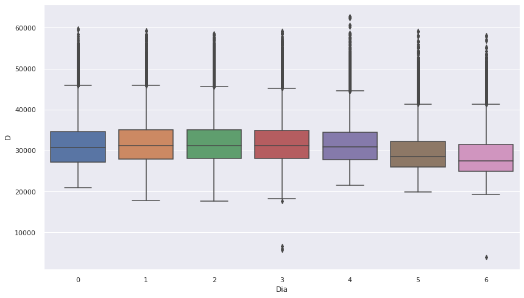

```python
sns.boxplot(data=df_selected_LOCAL, x='Dia', y='D')
```

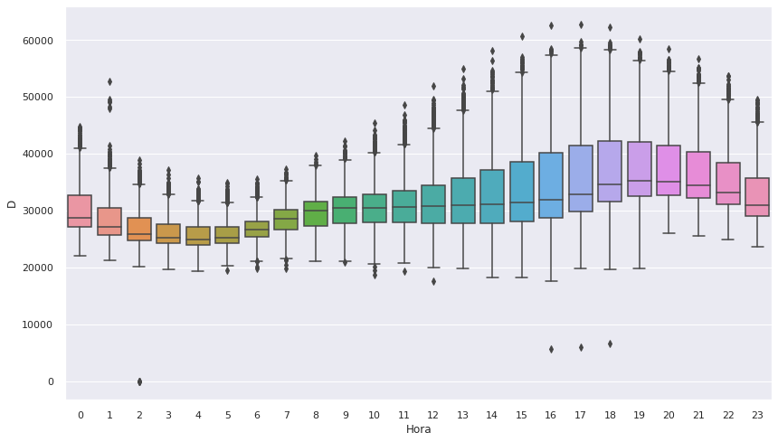

```python
sns.boxplot(data=df_selected_LOCAL_h, x='Hora', y='D')
```

### Estacionariedad

```python
def test_stationarity(timeseries):

    # Determining rolling statistics
    rolmean = timeseries.rolling(12).mean()
    rolstd = timeseries.rolling(12).std()
    # Plot rolling statistics:
    orig = plt.plot(timeseries, color='blue',label='Original')
    mean = plt.plot(rolmean, color='red', label='Rolling Mean')
    std = plt.plot(rolstd, color='black', label = 'Rolling Std')
    plt.legend(loc='best')
    plt.title('Rolling Mean & Standard Deviation')
    plt.show(block=False)
```

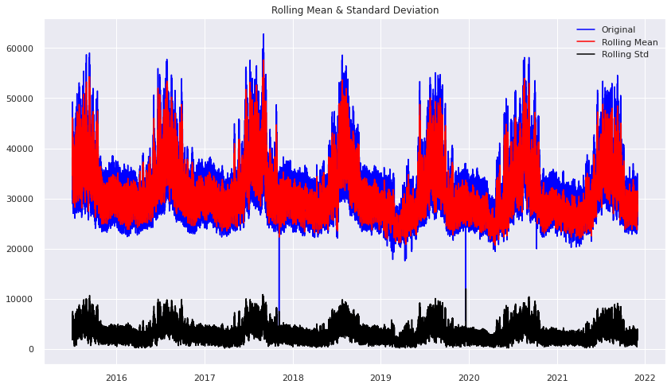

```python
test_stationarity(pd.DataFrame(df_selected_UTC["D"]))
```

```python
from statsmodels.tsa.stattools import adfuller

X = df_selected_UTC["D"]
result = adfuller(X)
print('ADF Statistic: %f' % result[0])
print('p-value: %f' % result[1])
print('Critical Values:')
for key, value in result[4].items():
    print('\t%s: %.3f' % (key, value))

if result[0] < result[4]["5%"]:
    print ("Reject Ho - Time Series is Stationary")
else:
    print ("Failed to Reject Ho - Time Series is Non-Stationary")
```

```
ADF Statistic: -10.082815
p-value: 0.000000
Critical Values:
	1%: -3.430
	5%: -2.862
	10%: -2.567
Reject Ho - Time Series is Stationary
```

```
No handles with labels found to put in legend.
No handles with labels found to put in legend.
```

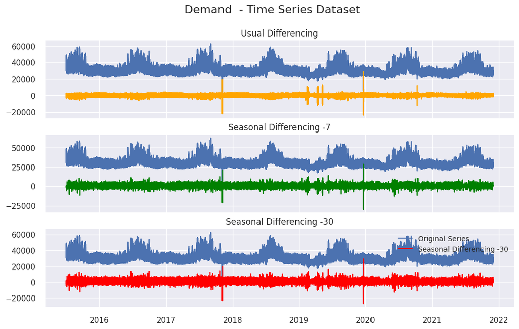

```python
# Plot
fig, axes = plt.subplots(3, 1, figsize=(12,7), dpi=100, sharex=True)

# Usual Differencing
axes[0].plot(df_selected_UTC['D'][:], label='Original Series')
axes[0].plot(df_selected_UTC['D'][:].diff(1), label='Usual Differencing', color = "orange")
axes[0].set_title('Usual Differencing')
plt.legend(loc='upper right', fontsize=10)


# Seasonal Differencing - 24 hour
axes[1].plot(df_selected_UTC['D'][:], label='Original Series')
axes[1].plot(df_selected_UTC['D'][:].diff(24), label='Seasonal Differencing -7', color='green')
axes[1].set_title('Seasonal Differencing -7')

plt.legend(loc='best', fontsize=10)


# Seasonal Differencing - 30 hour
axes[2].plot(df_selected_UTC['D'][:], label='Original Series')
axes[2].plot(df_selected_UTC['D'][:].diff(25), label='Seasonal Differencing -30', color='red')
axes[2].set_title('Seasonal Differencing -30')


plt.legend(loc='upper right', fontsize=10)
plt.suptitle('Demand  - Time Series Dataset', fontsize=16)
plt.show()
```

#### Gráficos finales

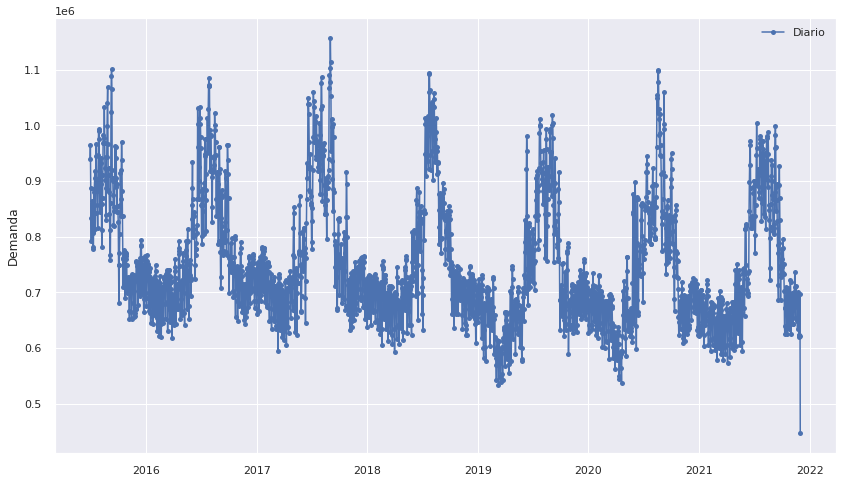

```python
inicio, final = '2015-07','2021-12'
fig,eje = plt.subplots()
eje.plot(df_selected_LOCAL_d.loc[inicio:final,'D'],marker='o',markersize=5,label='Diario')
eje.set_ylabel('Demanda')
eje.legend()
```

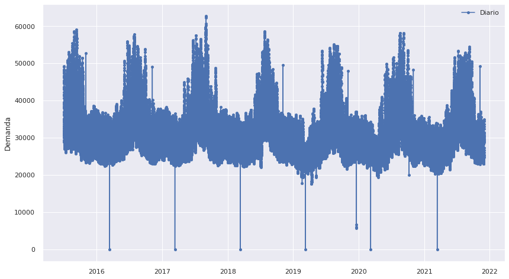

```python
inicio, final = '2015-07','2021-12'
fig,eje = plt.subplots()
eje.plot(df_selected_LOCAL_h.loc[inicio:final,'D'],marker='o',markersize=5,label='Diario')
eje.set_ylabel('Demanda')
eje.legend()
```

### Procesamiento datos modelización

Se observa como una vez elegida la columna UTC no existen problemas de duplicidades o eliminaciones de columnas por ajustes de horario en invierno y en verano

```python
df_selected_UTC
```

| UTC time | Region | Local date | Local hour | Local time | Time zone | D |
| --- | --- | --- | --- | --- | --- | --- |
| 2015-07-01 08:00:00 | CAL | 2015-07-01 | 1 | 2015-07-01 01:00:00 | Pacific | 38210 |
| 2015-07-01 09:00:00 | CAL | 2015-07-01 | 2 | 2015-07-01 02:00:00 | Pacific | 35171 |
| 2015-07-01 10:00:00 | CAL | 2015-07-01 | 3 | 2015-07-01 03:00:00 | Pacific | 33243 |
| 2015-07-01 11:00:00 | CAL | 2015-07-01 | 4 | 2015-07-01 04:00:00 | Pacific | 31955 |
| 2015-07-01 12:00:00 | CAL | 2015-07-01 | 5 | 2015-07-01 05:00:00 | Pacific | 31199 |
| ... | ... | ... | ... | ... | ... | ... |
| 2021-11-30 19:00:00 | CAL | 2021-11-30 | 11 | 2021-11-30 11:00:00 | Pacific | 29068 |
| 2021-11-30 20:00:00 | CAL | 2021-11-30 | 12 | 2021-11-30 12:00:00 | Pacific | 28769 |
| 2021-11-30 21:00:00 | CAL | 2021-11-30 | 13 | 2021-11-30 13:00:00 | Pacific | 29180 |
| 2021-11-30 22:00:00 | CAL | 2021-11-30 | 14 | 2021-11-30 14:00:00 | Pacific | 29719 |
| 2021-11-30 23:00:00 | CAL | 2021-11-30 | 15 | 2021-11-30 15:00:00 | Pacific | 30512 |

56272 rows × 6 columns

```python
df_selected_UTC = df_selected_UTC.drop(['Region','Local time', 'Time zone', 'Local date', 'Local hour'], axis = 1)
```

```python
df_selected_UTC
```

| UTC time | D |
| --- | --- |
| 2015-07-01 08:00:00 | 38210 |
| 2015-07-01 09:00:00 | 35171 |
| 2015-07-01 10:00:00 | 33243 |
| 2015-07-01 11:00:00 | 31955 |
| 2015-07-01 12:00:00 | 31199 |
| ... | ... |
| 2021-11-30 19:00:00 | 29068 |
| 2021-11-30 20:00:00 | 28769 |
| 2021-11-30 21:00:00 | 29180 |
| 2021-11-30 22:00:00 | 29719 |
| 2021-11-30 23:00:00 | 30512 |

56272 rows × 1 columns

```python
#Tratamiento de OUTLIERS con KNN
X = df_selected_UTC

clf = KNN(contamination=0.05)
clf.fit(X)
y_pred = clf.predict(X)
to_remove = X[y_pred == 1]
```

```python
to_remove
```

| UTC time | D |
| --- | --- |
| 2015-07-03 01:00:00 | 49266 |
| 2015-07-03 02:00:00 | 48231 |
| 2015-07-14 01:00:00 | 45993 |
| 2015-07-17 00:00:00 | 46492 |
| 2015-07-17 01:00:00 | 47095 |
| ... | ... |
| 2021-09-22 04:00:00 | 44895 |
| 2021-09-22 22:00:00 | 47189 |
| 2021-09-22 23:00:00 | 49343 |
| 2021-09-23 01:00:00 | 50027 |
| 2021-09-23 02:00:00 | 48380 |

1625 rows × 1 columns

```python
to_remove['Hora'] = to_remove.index.hour
to_remove
```

| UTC time | D | Hora |
| --- | --- | --- |
| 2015-07-03 01:00:00 | 49266 | 1 |
| 2015-07-03 02:00:00 | 48231 | 2 |
| 2015-07-14 01:00:00 | 45993 | 1 |
| 2015-07-17 00:00:00 | 46492 | 0 |
| 2015-07-17 01:00:00 | 47095 | 1 |
| ... | ... | ... |
| 2021-09-22 04:00:00 | 44895 | 4 |
| 2021-09-22 22:00:00 | 47189 | 22 |
| 2021-09-22 23:00:00 | 49343 | 23 |
| 2021-09-23 01:00:00 | 50027 | 1 |
| 2021-09-23 02:00:00 | 48380 | 2 |

1625 rows × 2 columns

```python
df_selected_UTC['Hora'] = df_selected_UTC.index.hour
```

```python
medias = df_selected_UTC.groupby(['Hora']).mean().round(0)
```

```python
medias
```

| Hora | D |
| --- | --- |
| 0 | 35356.0 |
| 1 | 36245.0 |
| 2 | 37137.0 |
| 3 | 37312.0 |
| 4 | 36763.0 |
| 5 | 35472.0 |
| 6 | 33306.0 |
| 7 | 30841.0 |
| 8 | 28791.0 |
| 9 | 27335.0 |
| 10 | 26348.0 |
| 11 | 25789.0 |
| 12 | 25765.0 |
| 13 | 26456.0 |
| 14 | 27798.0 |
| 15 | 29267.0 |
| 16 | 30256.0 |
| 17 | 30794.0 |
| 18 | 31194.0 |
| 19 | 31622.0 |
| 20 | 32110.0 |
| 21 | 32789.0 |
| 22 | 33616.0 |
| 23 | 34501.0 |

```python
result = pd.merge(
to_remove, medias, left_on="Hora", right_index=True, how="left", sort=False
)
```

```python
result
```

| UTC time | D_x | Hora | D_y |
| --- | --- | --- | --- |
| 2015-07-03 01:00:00 | 49266 | 1 | 36245.0 |
| 2015-07-03 02:00:00 | 48231 | 2 | 37137.0 |
| 2015-07-14 01:00:00 | 45993 | 1 | 36245.0 |
| 2015-07-17 00:00:00 | 46492 | 0 | 35356.0 |
| 2015-07-17 01:00:00 | 47095 | 1 | 36245.0 |
| ... | ... | ... | ... |
| 2021-09-22 04:00:00 | 44895 | 4 | 36763.0 |
| 2021-09-22 22:00:00 | 47189 | 22 | 33616.0 |
| 2021-09-22 23:00:00 | 49343 | 23 | 34501.0 |
| 2021-09-23 01:00:00 | 50027 | 1 | 36245.0 |
| 2021-09-23 02:00:00 | 48380 | 2 | 37137.0 |

1625 rows × 3 columns

```python
result = result.drop(['D_x', 'Hora'], axis = 1)
```

```python
result
```

| UTC time | D_y |
| --- | --- |
| 2015-07-03 01:00:00 | 36245.0 |
| 2015-07-03 02:00:00 | 37137.0 |
| 2015-07-14 01:00:00 | 36245.0 |
| 2015-07-17 00:00:00 | 35356.0 |
| 2015-07-17 01:00:00 | 36245.0 |
| ... | ... |
| 2021-09-22 04:00:00 | 36763.0 |
| 2021-09-22 22:00:00 | 33616.0 |
| 2021-09-22 23:00:00 | 34501.0 |
| 2021-09-23 01:00:00 | 36245.0 |
| 2021-09-23 02:00:00 | 37137.0 |

1625 rows × 1 columns

```python
result.rename(columns={'D_y':'D'},
               inplace=True)
```

```python
result
```

| UTC time | D |
| --- | --- |
| 2015-07-03 01:00:00 | 36245.0 |
| 2015-07-03 02:00:00 | 37137.0 |
| 2015-07-14 01:00:00 | 36245.0 |
| 2015-07-17 00:00:00 | 35356.0 |
| 2015-07-17 01:00:00 | 36245.0 |
| ... | ... |
| 2021-09-22 04:00:00 | 36763.0 |
| 2021-09-22 22:00:00 | 33616.0 |
| 2021-09-22 23:00:00 | 34501.0 |
| 2021-09-23 01:00:00 | 36245.0 |
| 2021-09-23 02:00:00 | 37137.0 |

1625 rows × 1 columns

```python
df_selected_UTC.update(result, join='left', overwrite=True, filter_func=None, errors='ignore')
```

```python
df_selected_UTC
```

| UTC time | D | Hora |
| --- | --- | --- |
| 2015-07-01 08:00:00 | 38210.0 | 8 |
| 2015-07-01 09:00:00 | 35171.0 | 9 |
| 2015-07-01 10:00:00 | 33243.0 | 10 |
| 2015-07-01 11:00:00 | 31955.0 | 11 |
| 2015-07-01 12:00:00 | 31199.0 | 12 |
| ... | ... | ... |
| 2021-11-30 19:00:00 | 29068.0 | 19 |
| 2021-11-30 20:00:00 | 28769.0 | 20 |
| 2021-11-30 21:00:00 | 29180.0 | 21 |
| 2021-11-30 22:00:00 | 29719.0 | 22 |
| 2021-11-30 23:00:00 | 30512.0 | 23 |

56272 rows × 2 columns

```python
df_selected_UTC.to_csv('predicción_diaria_transform.csv')
```

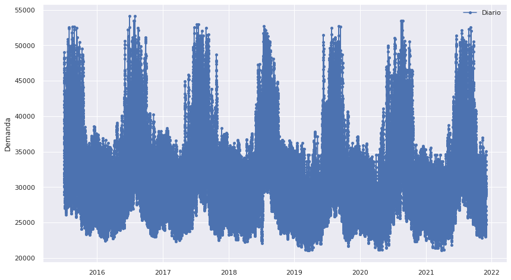

```python
inicio, final = '2015-07','2021-12'
fig,eje = plt.subplots()
eje.plot(df_selected_UTC.loc[inicio:final,'D'],marker='o',markersize=5,label='Diario')
eje.set_ylabel('Demanda')
eje.legend()
```

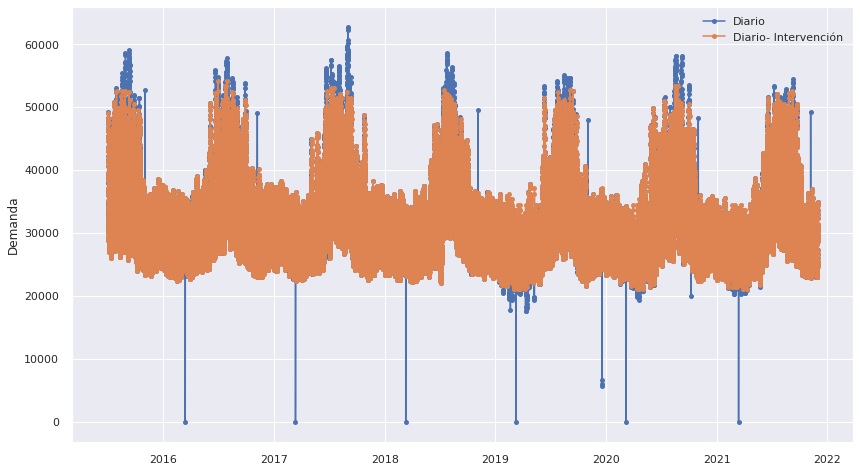

```python
#Grafico post tratamiento KNN

inicio, final = '2015-07','2021-12'

fig,eje = plt.subplots()
eje.plot(df_selected_LOCAL_h.loc[inicio:final,'D'],marker='o',markersize=5,label='Diario')
eje.plot(df_selected_UTC.loc[inicio:final,'D'],marker='o',markersize=5,label='Diario- Intervención')
eje.set_ylabel('Demanda')
eje.legend()
```

### ETS

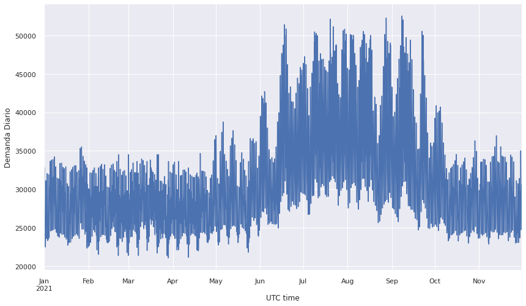

```python
eje = df_selected_UTC.loc['2021','D'].plot()
eje.set_ylabel('Demanda Diario')
```

Aunque se observa una componente estacional anual, ésta no va a afectar puesto que se van a utilizar como elementos de entrenamiento los meses previos al mes que se quiere predecir.

```python
from sktime.forecasting.base import ForecastingHorizon
from sktime.utils.plotting import plot_series
from sktime.forecasting.model_selection import temporal_train_test_split
```

```python
df_selected_ETS = df_selected_UTC.D['2021-10-01':]
```

```python
df_selected_ETS
```

```
UTC time
2021-10-01 00:00:00    37801.0
2021-10-01 01:00:00    39246.0
2021-10-01 02:00:00    39180.0
2021-10-01 03:00:00    38690.0
2021-10-01 04:00:00    36909.0
                        ...
2021-11-30 19:00:00    29068.0
2021-11-30 20:00:00    28769.0
2021-11-30 21:00:00    29180.0
2021-11-30 22:00:00    29719.0
2021-11-30 23:00:00    30512.0
Name: D, Length: 1464, dtype: float64
```

```
1314 150
```

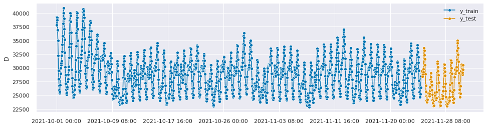

```python
#Separación entre Test y training

y_train, y_test = temporal_train_test_split(y = df_selected_ETS.astype('float64').to_period('H'), test_size=150)

#Visualización

plot_series(y_train, y_test, labels=["y_train", "y_test"])
print(y_train.shape[0], y_test.shape[0])
```

```python
from sktime.forecasting.ets import AutoETS
```

```python
# Especificamos el horizonte temporal de predicción. En python, el rango no incluye el cierre.

fh = np.arange(1,151)

# Algoritmo ETS
ETS_auto_model = AutoETS(auto=True, sp=24, n_jobs=-1)
```

```python
ETS_auto_model.fit(y_train)
```

```
AutoETS(auto=True, n_jobs=-1, sp=24)
```

```python
print(ETS_auto_model.summary())
```

```
                                 ETS Results
==============================================================================
Dep. Variable:                      D   No. Observations:                 1314
Model:                      ETS(MAdM)   Log Likelihood               -9770.452
Date:                Thu, 20 Jan 2022   AIC                          19602.904
Time:                        20:49:11   BIC                          19763.510
Sample:                    10-01-2021   HQIC                         19663.132
                         - 11-24-2021   Scale                            0.000
Covariance Type:               approx
=======================================================================================
                          coef    std err          z      P>|z|      [0.025      0.975]
---------------------------------------------------------------------------------------
smoothing_level         0.9999      0.060     16.654      0.000       0.882       1.118
smoothing_trend         0.7032      0.125      5.622      0.000       0.458       0.948
smoothing_seasonal   8.464e-05        nan        nan        nan         nan         nan
damping_trend           0.8000      0.052     15.499      0.000       0.699       0.901
initial_level        3.224e+04   1323.672     24.360      0.000    2.97e+04    3.48e+04
initial_trend          23.7337   1601.623      0.015      0.988   -3115.389    3162.857
initial_seasonal.0      0.9683      0.021     45.190      0.000       0.926       1.010
initial_seasonal.1      0.9431      0.021     44.775      0.000       0.902       0.984
initial_seasonal.2      0.9254      0.021     44.229      0.000       0.884       0.966
initial_seasonal.3      0.9155      0.021     43.624      0.000       0.874       0.957
initial_seasonal.4      0.9177      0.021     43.001      0.000       0.876       0.959
initial_seasonal.5      0.9239      0.022     42.414      0.000       0.881       0.967
initial_seasonal.6      0.9280      0.022     41.886      0.000       0.885       0.971
initial_seasonal.7      0.9226      0.022     41.439      0.000       0.879       0.966
initial_seasonal.8      0.9059      0.022     41.081      0.000       0.863       0.949
initial_seasonal.9      0.8610      0.021     40.793      0.000       0.820       0.902
initial_seasonal.10     0.8081      0.020     40.654      0.000       0.769       0.847
initial_seasonal.11     0.7838      0.019     40.553      0.000       0.746       0.822
initial_seasonal.12     0.7802      0.019     40.558      0.000       0.743       0.818
initial_seasonal.13     0.7906      0.019     40.666      0.000       0.753       0.829
initial_seasonal.14     0.8125      0.020     40.862      0.000       0.773       0.851
initial_seasonal.15     0.8439      0.021     41.153      0.000       0.804       0.884
initial_seasonal.16     0.8869      0.021     41.523      0.000       0.845       0.929
initial_seasonal.17     0.9454      0.023     41.986      0.000       0.901       0.990
initial_seasonal.18     1.0005      0.024     42.523      0.000       0.954       1.047
initial_seasonal.19     1.0382      0.024     43.129      0.000       0.991       1.085
initial_seasonal.20     1.0719      0.024     43.793      0.000       1.024       1.120
initial_seasonal.21     1.0808      0.024     44.420      0.000       1.033       1.129
initial_seasonal.22     1.0431      0.023     44.969      0.000       0.998       1.089
initial_seasonal.23     1.0000      0.022     45.341      0.000       0.957       1.043
===================================================================================
Ljung-Box (Q):                      491.61   Jarque-Bera (JB):             16987.37
Prob(Q):                              0.00   Prob(JB):                         0.00
Heteroskedasticity (H):               0.63   Skew:                             0.91
Prob(H) (two-sided):                  0.00   Kurtosis:                        20.52
===================================================================================

Warnings:
[1] Covariance matrix calculated using numerical (complex-step) differentiation.
```

```python
#Predicciones ajustadas al rango que hemos indicado anteriormente y que se corresponde con test

D_pred = ETS_auto_model.predict(fh)
print(D_pred)
```

```
2021-11-24 18:00    29320.553065
2021-11-24 19:00    29135.100436
2021-11-24 20:00    29076.729698
2021-11-24 21:00    29398.084445
2021-11-24 22:00    29967.357857
                        ...
2021-11-30 19:00    29183.829203
2021-11-30 20:00    29115.621601
2021-11-30 21:00    29429.533421
2021-11-30 22:00    29992.998741
2021-11-30 23:00    30793.190162
Freq: H, Length: 150, dtype: float64
```

```
(<Figure size 1152x288 with 1 Axes>,
```

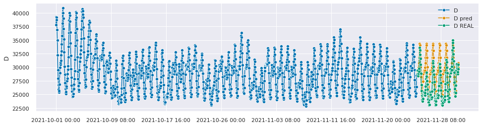

```python
#Plotear los datos y establecer las etiquetas

plot_series(y_train, D_pred, y_test, labels=["D", "D pred", "D REAL"])
```

```
(<Figure size 1152x288 with 1 Axes>,
```

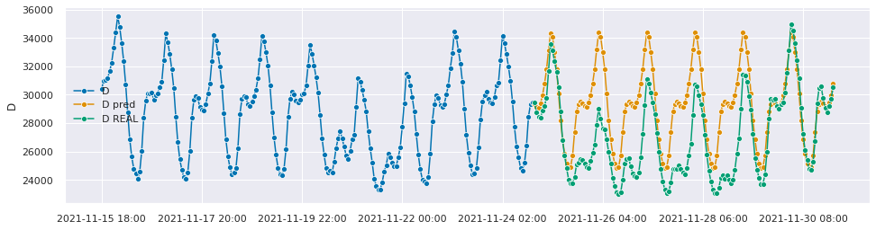

```python
plot_series(y_train['2021-11-15 18:00':], D_pred, y_test, labels=["D", "D pred", "D REAL"])
```

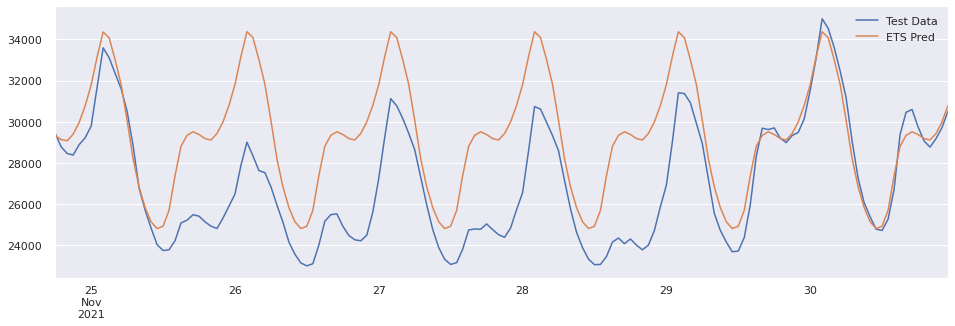

```python
y_test.rename("Test Data").plot(figsize = (16,5), legend=True)
D_pred.rename("ETS Pred").plot(legend = True);
```

```python
from sklearn.metrics import mean_squared_error
from statsmodels.tools.eval_measures import rmse
from sktime.performance_metrics.forecasting import mean_absolute_percentage_error
from sktime.performance_metrics.forecasting import MeanSquaredError
```

```python
ets_rmse_error = rmse(y_test, D_pred)
ets_mse_error = ets_rmse_error**2
ets_mape_error = mean_absolute_percentage_error(y_test, D_pred)
mean_value = df_selected_ETS.mean()

print(f'MSE Error: {ets_mse_error}\nRMSE Error: {ets_mse_error}\nMean: {mean_value}\nMAPE Error: {ets_mape_error}')
```

```
MSE Error: 9003237.614133287
RMSE Error: 9003237.614133287
Mean: 28632.12226775956
MAPE Error: 0.08501978827639917
```

```python
pred = np.arange(151,670)

Predicciones = ETS_auto_model.predict(pred)
print(Predicciones)
```

```
2021-12-01 00:00    31803.042504
2021-12-01 01:00    33172.605108
2021-12-01 02:00    34373.669790
2021-12-01 03:00    34087.937114
2021-12-01 04:00    33017.383803
                        ...
2021-12-22 10:00    25143.779818
2021-12-22 11:00    24812.494046
2021-12-22 12:00    24925.966692
2021-12-22 13:00    25698.525966
2021-12-22 14:00    27381.201242
Freq: H, Length: 519, dtype: float64
```

```
(<Figure size 1152x288 with 1 Axes>,
```

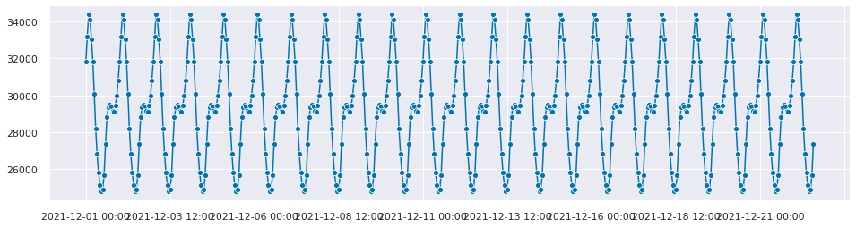

```python
plot_series(Predicciones)
```

### ARIMA

```python
# Sktime fucntions
# Forecast horizon and Split function
from sktime.forecasting.base import ForecastingHorizon
from sktime.forecasting.model_selection import temporal_train_test_split
from sktime.transformations.series.boxcox import LogTransformer
from sktime.utils.plotting import plot_series
```

```python
df_selected_UTC
```

| UTC time | D | Hora |
| --- | --- | --- |
| 2015-07-01 08:00:00 | 38210.0 | 8 |
| 2015-07-01 09:00:00 | 35171.0 | 9 |
| 2015-07-01 10:00:00 | 33243.0 | 10 |
| 2015-07-01 11:00:00 | 31955.0 | 11 |
| 2015-07-01 12:00:00 | 31199.0 | 12 |
| ... | ... | ... |
| 2021-11-30 19:00:00 | 29068.0 | 19 |
| 2021-11-30 20:00:00 | 28769.0 | 20 |
| 2021-11-30 21:00:00 | 29180.0 | 21 |
| 2021-11-30 22:00:00 | 29719.0 | 22 |
| 2021-11-30 23:00:00 | 30512.0 | 23 |

56272 rows × 2 columns

```python
#df_selected_ARIMA = df_selected_UTC['D']['2021-11-01':]
df_selected_ARIMA = df_selected_UTC['D']['2021-10-01':]
```

```python
df_selected_ARIMA = pd.DataFrame(df_selected_ARIMA)
```

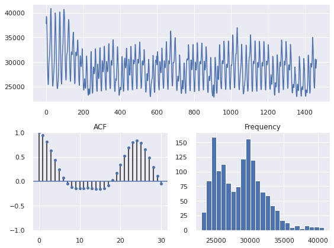

```python
from pmdarima.utils import tsdisplay

tsdisplay(df_selected_ARIMA, lag_max=30)
```

```
1314 150
```

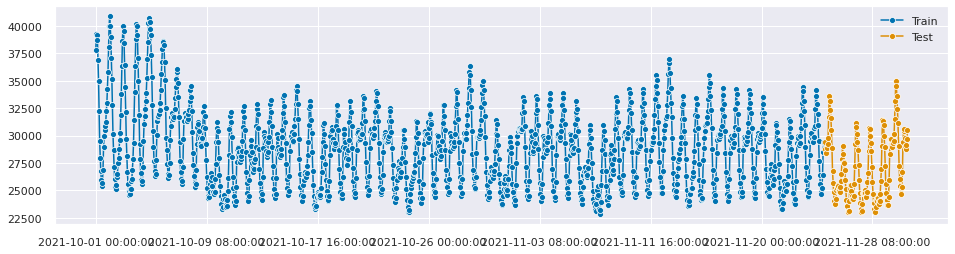

```python
train_data = df_selected_ARIMA[:len(df_selected_ARIMA)-150]
test_data = df_selected_ARIMA[len(df_selected_ARIMA)-150:]

plot_series(train_data, test_data , labels=["Train", "Test"])
# Time Series Size
print(train_data.shape[0], test_data.shape[0])
```

```python
from pmdarima.arima.utils import ndiffs

# Estimate the number of differences using an ADF test:
n_adf = ndiffs(df_selected_ARIMA, test='adf')  # -> 0

n_adf
```

```
0
```

```python
model = pm.auto_arima(train_data, start_p=1, start_q=1,
                      test='adf',       # use adftest to find optimal 'd'
                      max_p=3, max_q=3, # maximum p and q
                      m=24,              # frequency of series
                      d=None,           # let model determine 'd'
                      seasonal=False,   # No Seasonality
                      start_P=0,
                      D=None,
                      trace=True,
                      error_action='ignore',
                      suppress_warnings=True,
                      stepwise=True)

print(model.summary())
```

```
Performing stepwise search to minimize aic
 ARIMA(1,0,1)(0,0,0)[0]             : AIC=21127.645, Time=0.43 sec
 ARIMA(0,0,0)(0,0,0)[0]             : AIC=30735.342, Time=0.02 sec
 ARIMA(1,0,0)(0,0,0)[0]             : AIC=inf, Time=0.04 sec
 ARIMA(0,0,1)(0,0,0)[0]             : AIC=inf, Time=0.33 sec
 ARIMA(2,0,1)(0,0,0)[0]             : AIC=20601.075, Time=0.43 sec
 ARIMA(2,0,0)(0,0,0)[0]             : AIC=inf, Time=0.15 sec
 ARIMA(3,0,1)(0,0,0)[0]             : AIC=20367.725, Time=0.78 sec
 ARIMA(3,0,0)(0,0,0)[0]             : AIC=inf, Time=0.10 sec
 ARIMA(3,0,2)(0,0,0)[0]             : AIC=20605.074, Time=1.31 sec
 ARIMA(2,0,2)(0,0,0)[0]             : AIC=20573.859, Time=0.45 sec
 ARIMA(3,0,1)(0,0,0)[0] intercept   : AIC=20342.785, Time=0.93 sec
 ARIMA(2,0,1)(0,0,0)[0] intercept   : AIC=20359.267, Time=0.26 sec
 ARIMA(3,0,0)(0,0,0)[0] intercept   : AIC=20340.783, Time=0.56 sec
 ARIMA(2,0,0)(0,0,0)[0] intercept   : AIC=20396.144, Time=0.30 sec

Best model:  ARIMA(3,0,0)(0,0,0)[0] intercept
Total fit time: 6.130 seconds
                               SARIMAX Results
==============================================================================
Dep. Variable:                      y   No. Observations:                 1314
Model:               SARIMAX(3, 0, 0)   Log Likelihood              -10165.391
Date:                Thu, 20 Jan 2022   AIC                          20340.783
Time:                        20:49:20   BIC                          20366.687
Sample:                             0   HQIC                         20350.497
                               - 1314
Covariance Type:                  opg
==============================================================================
                 coef    std err          z      P>|z|      [0.025      0.975]
------------------------------------------------------------------------------
intercept   2176.5805    150.504     14.462      0.000    1881.597    2471.563
ar.L1          1.9360      0.023     84.486      0.000       1.891       1.981
ar.L2         -1.2179      0.043    -28.499      0.000      -1.302      -1.134
ar.L3          0.2064      0.024      8.611      0.000       0.159       0.253
sigma2      3.041e+05      0.451   6.74e+05      0.000    3.04e+05    3.04e+05
===================================================================================
Ljung-Box (L1) (Q):                   0.01   Jarque-Bera (JB):               101.77
Prob(Q):                              0.92   Prob(JB):                         0.00
Heteroskedasticity (H):               1.00   Skew:                            -0.18
Prob(H) (two-sided):                  0.99   Kurtosis:                         4.32
===================================================================================

Warnings:
[1] Covariance matrix calculated using the outer product of gradients (complex-step).
[2] Covariance matrix is singular or near-singular, with condition number 1.15e+21. Standard errors may be unstable.
```

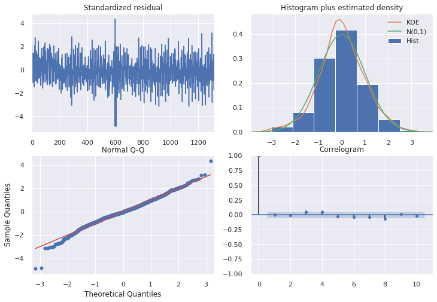

```python
model.plot_diagnostics(figsize=(12,8))
plt.show()
```

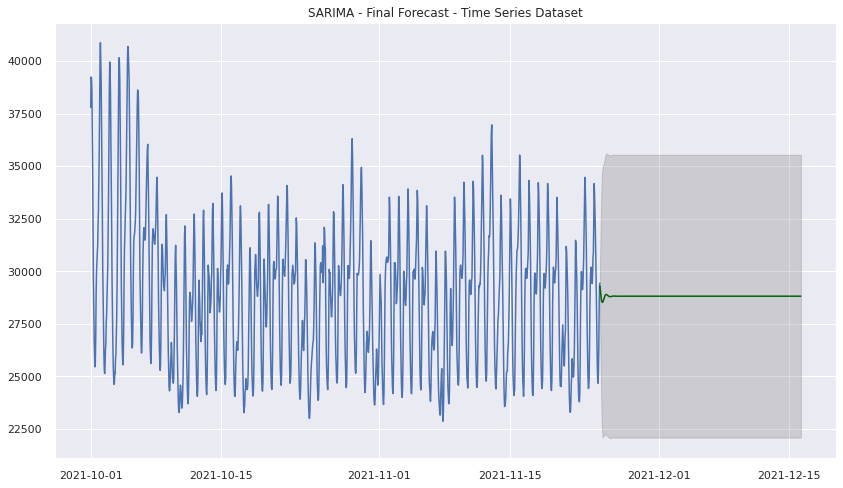

```python
# Forecast
n_periods = 519
fitted, confint = model.predict(n_periods=n_periods, return_conf_int=True)
index_of_fc = pd.date_range(train_data.index[-1], periods = n_periods, freq='H')

# make series for plotting purpose
fitted_series = pd.Series(fitted, index=index_of_fc)
lower_series = pd.Series(confint[:, 0], index=index_of_fc)
upper_series = pd.Series(confint[:, 1], index=index_of_fc)

# Plot
plt.plot(train_data)
plt.plot(fitted_series, color='darkgreen')
plt.fill_between(lower_series.index,
                 lower_series,
                 upper_series,
                 color='k', alpha=.15)

plt.title("SARIMA - Final Forecast - Time Series Dataset")
plt.show()
```

```python
fitted_series
```

```
2021-11-24 17:00:00    29289.770081
2021-11-24 18:00:00    29088.628192
2021-11-24 19:00:00    28894.440265
2021-11-24 20:00:00    28733.287612
2021-11-24 21:00:00    28616.289785
                           ...
2021-12-16 03:00:00    28811.895184
2021-12-16 04:00:00    28811.895184
2021-12-16 05:00:00    28811.895184
2021-12-16 06:00:00    28811.895184
2021-12-16 07:00:00    28811.895184
Freq: H, Length: 519, dtype: float64
```

```python
# Seasonal - fit stepwise auto-ARIMA. ESTE ES EL MÁS ADECUADO NO BOERARRR
smodel = pm.auto_arima(train_data, start_p=1, start_q=1,
                         test='adf',
                         max_p=4, max_q=4, m=24,
                         start_P=0, seasonal=True,
                         d=None, D=None, trace=True, stationarity = True,
                         error_action='ignore',
                         suppress_warnings=True,
                         stepwise=True)

smodel.summary()
```

```
Performing stepwise search to minimize aic
 ARIMA(1,0,1)(0,0,1)[24] intercept   : AIC=20457.765, Time=8.59 sec
 ARIMA(0,0,0)(0,0,0)[24] intercept   : AIC=25138.296, Time=0.04 sec
 ARIMA(1,0,0)(1,0,0)[24] intercept   : AIC=inf, Time=14.24 sec
 ARIMA(0,0,1)(0,0,1)[24] intercept   : AIC=inf, Time=5.41 sec
 ARIMA(0,0,0)(0,0,0)[24]             : AIC=30735.342, Time=0.02 sec
 ARIMA(1,0,1)(0,0,0)[24] intercept   : AIC=21126.155, Time=1.70 sec
 ARIMA(1,0,1)(1,0,1)[24] intercept   : AIC=19775.374, Time=17.37 sec
 ARIMA(1,0,1)(1,0,0)[24] intercept   : AIC=19480.175, Time=23.60 sec
 ARIMA(1,0,1)(2,0,0)[24] intercept   : AIC=inf, Time=nan sec
 ARIMA(1,0,1)(2,0,1)[24] intercept   : AIC=inf, Time=61.14 sec
 ARIMA(0,0,1)(1,0,0)[24] intercept   : AIC=23458.146, Time=7.81 sec
 ARIMA(2,0,1)(1,0,0)[24] intercept   : AIC=19822.772, Time=25.49 sec
 ARIMA(1,0,2)(1,0,0)[24] intercept   : AIC=19433.567, Time=17.10 sec
 ARIMA(1,0,2)(0,0,0)[24] intercept   : AIC=20695.363, Time=1.07 sec
 ARIMA(1,0,2)(2,0,0)[24] intercept   : AIC=20161.253, Time=132.18 sec
 ARIMA(1,0,2)(1,0,1)[24] intercept   : AIC=19431.980, Time=15.90 sec
 ARIMA(1,0,2)(0,0,1)[24] intercept   : AIC=20093.391, Time=7.30 sec
 ARIMA(1,0,2)(2,0,1)[24] intercept   : AIC=20202.316, Time=58.89 sec
 ARIMA(1,0,2)(1,0,2)[24] intercept   : AIC=19482.869, Time=61.19 sec
 ARIMA(1,0,2)(0,0,2)[24] intercept   : AIC=19794.149, Time=36.19 sec
 ARIMA(1,0,2)(2,0,2)[24] intercept   : AIC=20230.936, Time=86.74 sec
 ARIMA(0,0,2)(1,0,1)[24] intercept   : AIC=23824.849, Time=15.48 sec
 ARIMA(2,0,2)(1,0,1)[24] intercept   : AIC=19821.216, Time=19.95 sec
 ARIMA(1,0,3)(1,0,1)[24] intercept   : AIC=inf, Time=17.09 sec
 ARIMA(0,0,1)(1,0,1)[24] intercept   : AIC=22575.667, Time=10.36 sec
 ARIMA(0,0,3)(1,0,1)[24] intercept   : AIC=inf, Time=15.77 sec
 ARIMA(2,0,1)(1,0,1)[24] intercept   : AIC=19807.913, Time=16.63 sec
 ARIMA(2,0,3)(1,0,1)[24] intercept   : AIC=inf, Time=22.04 sec
 ARIMA(1,0,2)(1,0,1)[24]             : AIC=19162.914, Time=12.24 sec
 ARIMA(1,0,2)(0,0,1)[24]             : AIC=20141.036, Time=6.41 sec
 ARIMA(1,0,2)(1,0,0)[24]             : AIC=19373.652, Time=4.61 sec
 ARIMA(1,0,2)(2,0,1)[24]             : AIC=inf, Time=50.19 sec
 ARIMA(1,0,2)(1,0,2)[24]             : AIC=inf, Time=53.14 sec
 ARIMA(1,0,2)(0,0,0)[24]             : AIC=20742.673, Time=0.41 sec
 ARIMA(1,0,2)(0,0,2)[24]             : AIC=19840.639, Time=29.84 sec
 ARIMA(1,0,2)(2,0,0)[24]             : AIC=19292.472, Time=17.32 sec
 ARIMA(1,0,2)(2,0,2)[24]             : AIC=inf, Time=92.78 sec
 ARIMA(0,0,2)(1,0,1)[24]             : AIC=inf, Time=20.01 sec
 ARIMA(1,0,1)(1,0,1)[24]             : AIC=19329.957, Time=9.04 sec
 ARIMA(2,0,2)(1,0,1)[24]             : AIC=19153.155, Time=13.41 sec
 ARIMA(2,0,2)(0,0,1)[24]             : AIC=20038.106, Time=6.45 sec
 ARIMA(2,0,2)(1,0,0)[24]             : AIC=19375.929, Time=6.62 sec
 ARIMA(2,0,2)(2,0,1)[24]             : AIC=19369.405, Time=46.42 sec
 ARIMA(2,0,2)(1,0,2)[24]             : AIC=inf, Time=54.19 sec
 ARIMA(2,0,2)(0,0,0)[24]             : AIC=20573.859, Time=0.45 sec
 ARIMA(2,0,2)(0,0,2)[24]             : AIC=19772.872, Time=35.82 sec
 ARIMA(2,0,2)(2,0,0)[24]             : AIC=19467.089, Time=20.69 sec
 ARIMA(2,0,2)(2,0,2)[24]             : AIC=inf, Time=51.43 sec
 ARIMA(2,0,1)(1,0,1)[24]             : AIC=19157.759, Time=9.97 sec
 ARIMA(3,0,2)(1,0,1)[24]             : AIC=19275.753, Time=16.20 sec
 ARIMA(2,0,3)(1,0,1)[24]             : AIC=inf, Time=19.85 sec
 ARIMA(1,0,3)(1,0,1)[24]             : AIC=19218.738, Time=15.42 sec
 ARIMA(3,0,1)(1,0,1)[24]             : AIC=19203.337, Time=11.36 sec
 ARIMA(3,0,3)(1,0,1)[24]             : AIC=inf, Time=13.98 sec

Best model:  ARIMA(2,0,2)(1,0,1)[24]
Total fit time: 1356.217 seconds
```

SARIMAX Results

| Dep. Variable: | y | No. Observations: | 1314 |
| --- | --- | --- | --- |
| Model: | SARIMAX(2, 0, 2)x(1, 0, [1], 24) | Log Likelihood | -9569.578 |
| Date: | Thu, 20 Jan 2022 | AIC | 19153.155 |
| Time: | 21:11:58 | BIC | 19189.421 |
| Sample: | 0 | HQIC | 19166.755 |
|  | - 1314 |  |  |
| Covariance Type: | opg |  |  |

|  | coef | std err | z | P>\|z\| | [0.025 | 0.975] |
| --- | --- | --- | --- | --- | --- | --- |
| ar.L1 | 1.4356 | 0.074 | 19.399 | 0.000 | 1.291 | 1.581 |
| ar.L2 | -0.4768 | 0.072 | -6.595 | 0.000 | -0.618 | -0.335 |
| ma.L1 | 0.1218 | 0.078 | 1.564 | 0.118 | -0.031 | 0.274 |
| ma.L2 | 0.0877 | 0.053 | 1.641 | 0.101 | -0.017 | 0.193 |
| ar.S.L24 | 0.9988 | 0.000 | 2919.506 | 0.000 | 0.998 | 0.999 |
| ma.S.L24 | -0.7608 | 0.016 | -46.787 | 0.000 | -0.793 | -0.729 |
| sigma2 | 1.189e+05 | 2985.447 | 39.814 | 0.000 | 1.13e+05 | 1.25e+05 |

| Ljung-Box (L1) (Q): | 0.06 | Jarque-Bera (JB): | 1150.26 |
| --- | --- | --- | --- |
| Prob(Q): | 0.80 | Prob(JB): | 0.00 |
| Heteroskedasticity (H): | 0.77 | Skew: | -0.68 |
| Prob(H) (two-sided): | 0.01 | Kurtosis: | 7.38 |

Warnings:  
[1] Covariance matrix calculated using the outer product of gradients (complex-step).

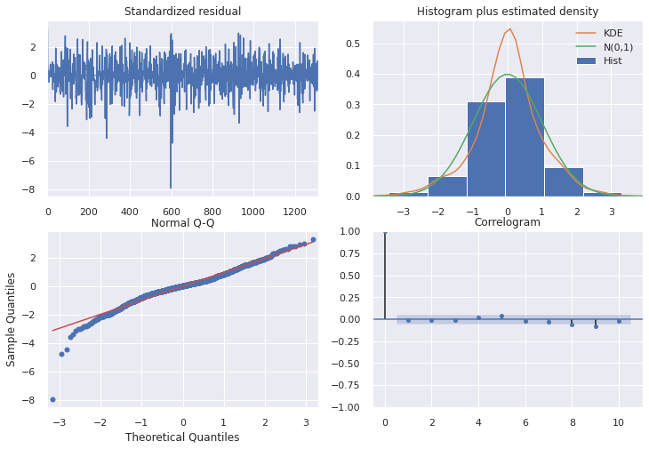

```python
smodel.plot_diagnostics(figsize=(12,8))
plt.show()
```

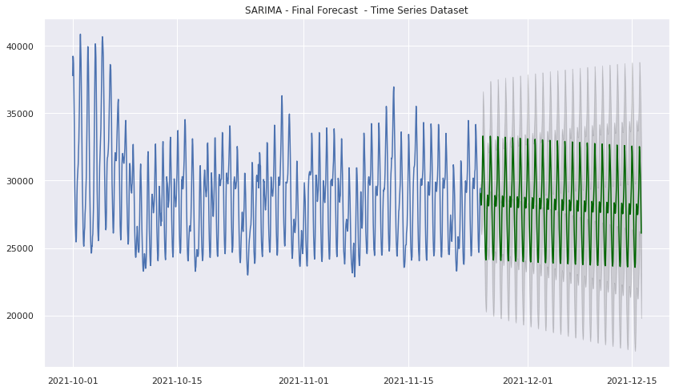

```python
# Forecast
n_periods = 519
fitted, confint = smodel.predict(n_periods=n_periods, return_conf_int=True)
index_of_fc = pd.date_range(train_data.index[-1], periods = n_periods, freq='H')

# make series for plotting purpose
fitted_series = pd.Series(fitted, index=index_of_fc)
lower_series = pd.Series(confint[:, 0], index=index_of_fc)
upper_series = pd.Series(confint[:, 1], index=index_of_fc)

# Plot
plt.plot(train_data)
plt.plot(fitted_series, color='darkgreen')
plt.fill_between(lower_series.index,
                 lower_series,
                 upper_series,
                 color='k', alpha=.15)

plt.title("SARIMA - Final Forecast  - Time Series Dataset")
plt.show()
```

```python
arima_pred = fitted_series.rename("ARIMA Predictions")
arima_pred[1:151]
```

```
2021-11-24 18:00:00    28496.515389
2021-11-24 19:00:00    28182.891365
2021-11-24 20:00:00    28207.082544
2021-11-24 21:00:00    28701.008300
2021-11-24 22:00:00    29374.659222
                           ...
2021-11-30 19:00:00    27962.231564
2021-11-30 20:00:00    28021.094662
2021-11-30 21:00:00    28527.635414
2021-11-30 22:00:00    29203.033224
2021-11-30 23:00:00    29973.128656
Freq: H, Name: ARIMA Predictions, Length: 150, dtype: float64
```

```python
test_data['D']
```

```
2021-11-24 18:00:00    29439.0
2021-11-24 19:00:00    28779.0
2021-11-24 20:00:00    28457.0
2021-11-24 21:00:00    28384.0
2021-11-24 22:00:00    28888.0
                        ...
2021-11-30 19:00:00    29068.0
2021-11-30 20:00:00    28769.0
2021-11-30 21:00:00    29180.0
2021-11-30 22:00:00    29719.0
2021-11-30 23:00:00    30512.0
Length: 150, dtype: float64
```

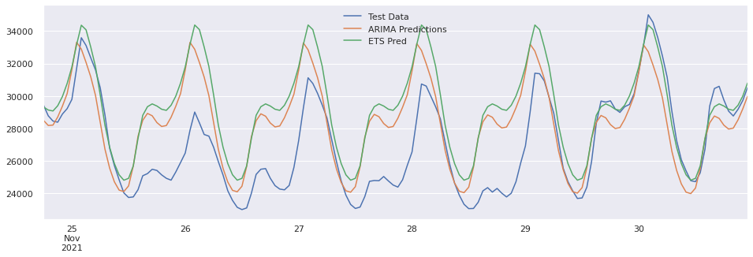

```python
test_data['D'].rename("Test Data").plot(figsize = (16,5), legend=True)
arima_pred[1:151].plot(legend = True)
D_pred.rename("ETS Pred").plot(legend = True);
```

```python
arima_rmse_error = rmse(test_data['D'], arima_pred[1:151])
arima_mse_error = arima_rmse_error**2
arima_mape_error = mean_absolute_percentage_error(test_data['D'], arima_pred[1:151])
mean_value = df_selected_ARIMA['D'].mean()


print(f'MSE Error: {arima_mse_error}\nRMSE Error: {arima_rmse_error}\nMean: {mean_value}')
```

```
MSE Error: 6553096.008270987
RMSE Error: 2559.90156222285
Mean: 28632.12226775956
```

```python
test_data['ARIMA_Predictions'] = arima_pred
```

### PROPHET

```python
df_pr = df_selected_UTC['D']['2021-10-01':].reset_index()
```

```python
df_pr.columns = ['ds','y'] # To use prophet column names should be like that
```

```python
train_data_pr = df_pr.iloc[:len(df_pr)-150]
test_data_pr = df_pr.iloc[len(df_pr)-150:]
```

```python
from fbprophet import Prophet
```

```python
m = Prophet()
m.fit(train_data_pr)
future = m.make_future_dataframe(periods=518,freq='H')
prophet_pred = m.predict(future)
```

```
INFO:fbprophet:Disabling yearly seasonality. Run prophet with yearly_seasonality=True to override this.
```

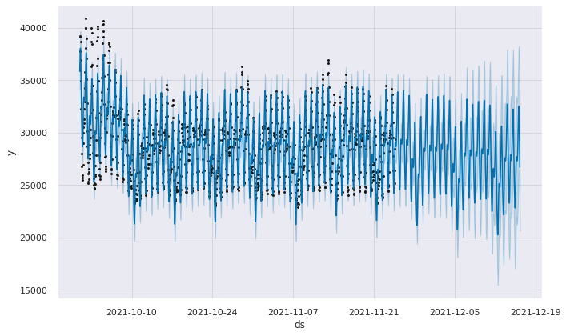

```python
fig1 = m.plot(prophet_pred, uncertainty=True)
```

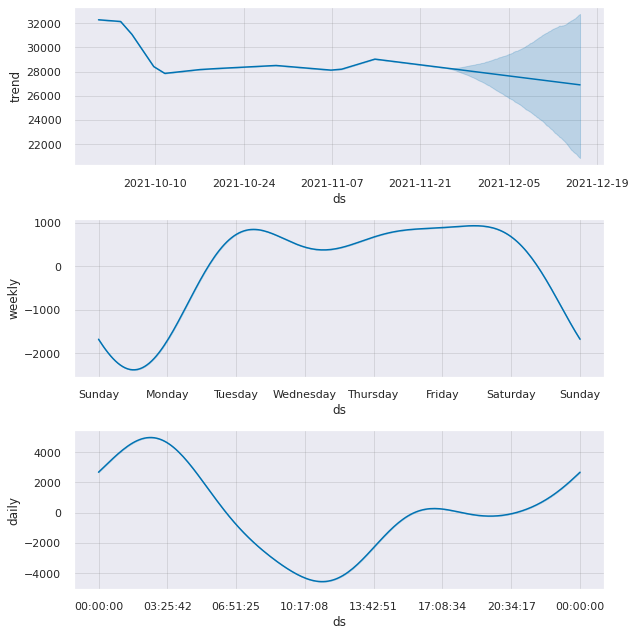

```python
# Python
fig2 = m.plot_components(prophet_pred)
```

```python
prophet_pred = pd.DataFrame({"Date" : prophet_pred[-518:]['ds'], "Pred" : prophet_pred[-518:]["yhat"]})
```

```python
prophet_pred = prophet_pred.set_index("Date")
```

```python
prophet_pred.index.freq = "H"
```

```python
prophet_pred
```

| Date | Pred |
| --- | --- |
| 2021-11-24 18:00:00 | 28870.801045 |
| 2021-11-24 19:00:00 | 28666.170254 |
| 2021-11-24 20:00:00 | 28682.185184 |
| 2021-11-24 21:00:00 | 28974.097775 |
| 2021-11-24 22:00:00 | 29549.037754 |
| ... | ... |
| 2021-12-16 03:00:00 | 32514.056808 |
| 2021-12-16 04:00:00 | 31648.784688 |
| 2021-12-16 05:00:00 | 30076.908564 |
| 2021-12-16 06:00:00 | 28289.451567 |
| 2021-12-16 07:00:00 | 26691.876834 |

518 rows × 1 columns

```python
test_data["Prophet_Predictions"] = prophet_pred['Pred'][0:150].values
```

```python
test_data["Prophet_Predictions"]
```

```
2021-11-24 18:00:00    28870.801045
2021-11-24 19:00:00    28666.170254
2021-11-24 20:00:00    28682.185184
2021-11-24 21:00:00    28974.097775
2021-11-24 22:00:00    29549.037754
                           ...
2021-11-30 19:00:00    28279.130566
2021-11-30 20:00:00    28243.729628
2021-11-30 21:00:00    28485.685651
2021-11-30 22:00:00    29012.732549
2021-11-30 23:00:00    29859.561704
Name: Prophet_Predictions, Length: 150, dtype: float64
```

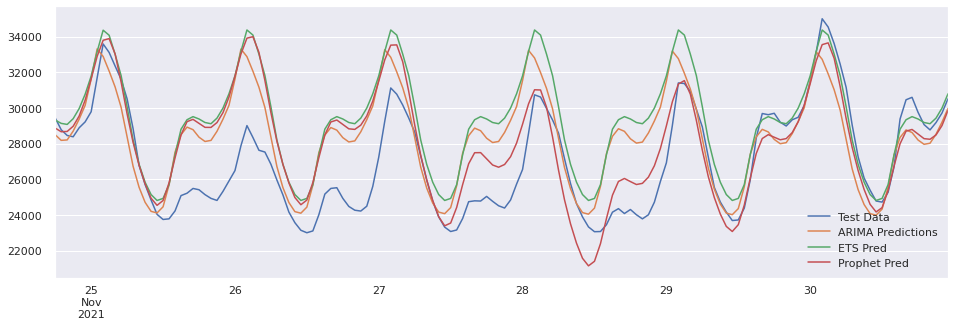

```python
plt.figure(figsize=(16,5))
test_data['D'].rename("Test Data").plot(figsize = (16,5), legend=True)
arima_pred[1:151].plot(legend = True)
D_pred.rename("ETS Pred").plot(legend = True);
test_data["Prophet_Predictions"].rename("Prophet Pred").plot(legend = True)
```

```python
from statsmodels.tools.eval_measures import rmse

prophet_rmse_error = rmse(test_data['D'], test_data["Prophet_Predictions"])
prophet_mse_error = prophet_rmse_error**2
mean_value = df_selected_ARIMA['D'].mean()
prophet_mape_error = mean_absolute_percentage_error(test_data['D'], test_data["Prophet_Predictions"] )

print(f'MSE Error: {prophet_mse_error}\nRMSE Error: {prophet_rmse_error}\nMean: {mean_value}\nMAPE Error: {prophet_mape_error}')
```

```
MSE Error: 5079383.087464612
RMSE Error: 2253.7486744232624
Mean: 28632.12226775956
MAPE Error: 0.0629916920962278
```

```python
mean_absolute_percentage_error(test_data['D'], test_data["Prophet_Predictions"] )
```

```
0.0629916920962278
```

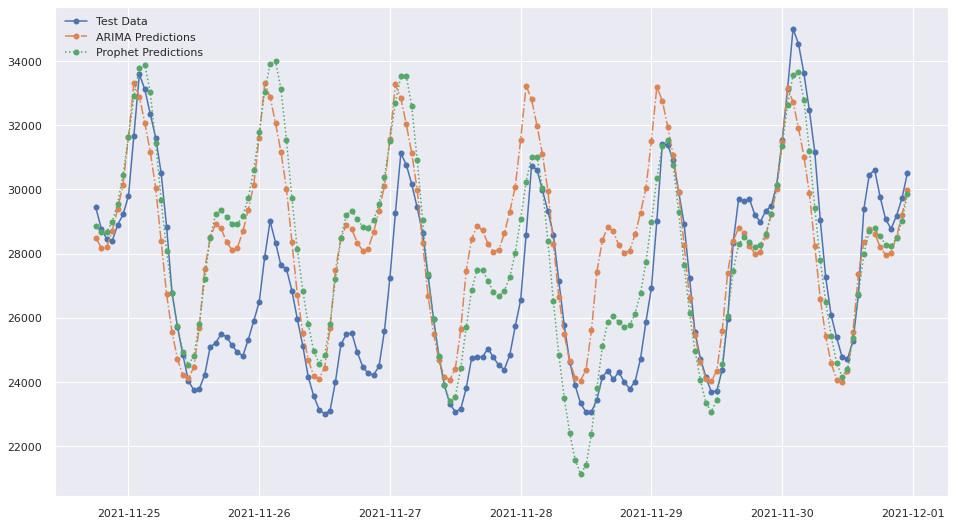

```python
plt.figure(figsize=(16,9))
plt.plot_date(test_data.index, test_data["D"], linestyle="-", label='Test Data')
plt.plot_date(test_data.index, test_data["ARIMA_Predictions"], linestyle="-.", label='ARIMA Predictions')
plt.plot_date(test_data.index, test_data["Prophet_Predictions"], linestyle=":", label='Prophet Predictions')
plt.legend()
plt.show()
```

### Predicciones

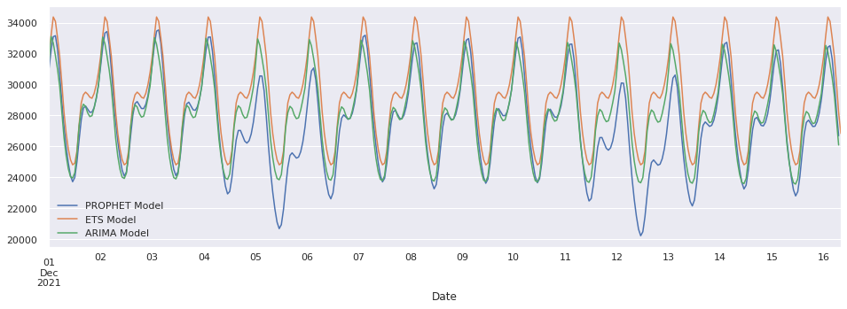

```python
plt.figure(figsize=(16,5))
prophet_pred['Pred'][150:].rename("PROPHET Model").plot(figsize = (16,5), legend=True)
Predicciones[:369].rename("ETS Model").plot(figsize = (16,5), legend=True)
fitted_series[151:].rename("ARIMA Model").plot(figsize = (16,5), legend=True)
```

```python
predicciones_horarias = pd.DataFrame(prophet_pred['Pred'][150:].rename("PROPHET Model"))
predicciones_horarias["ETS Model"] = Predicciones[:368]
predicciones_horarias["ARIMA Model"] = fitted_series[151:]
```

```python
Predicciones[:368]
```

```
2021-12-01 00:00    31803.042504
2021-12-01 01:00    33172.605108
2021-12-01 02:00    34373.669790
2021-12-01 03:00    34087.937114
2021-12-01 04:00    33017.383803
                        ...
2021-12-16 03:00    34087.937114
2021-12-16 04:00    33017.383803
2021-12-16 05:00    31816.978229
2021-12-16 06:00    30067.488105
2021-12-16 07:00    28205.398310
Freq: H, Length: 368, dtype: float64
```

```python
fitted_series[151:]
```

```
2021-12-01 00:00:00    31434.381435
2021-12-01 01:00:00    33112.535618
2021-12-01 02:00:00    32688.843887
2021-12-01 03:00:00    31873.568717
2021-12-01 04:00:00    30984.046614
                           ...
2021-12-16 03:00:00    31315.504290
2021-12-16 04:00:00    30441.556549
2021-12-16 05:00:00    29327.825134
2021-12-16 06:00:00    27705.107535
2021-12-16 07:00:00    26094.719341
Freq: H, Length: 368, dtype: float64
```

```python
predicciones_horarias.index = predicciones_horarias.index.tz_localize("UTC")
```

```python
predicciones_horarias
```

| Date | PROPHET Model | ETS Model | ARIMA Model |
| --- | --- | --- | --- |
| 2021-12-01 00:00:00+00:00 | 31006.493258 | 31803.042504 | 31434.381435 |
| 2021-12-01 01:00:00+00:00 | 32231.614968 | 33172.605108 | 33112.535618 |
| 2021-12-01 02:00:00+00:00 | 33097.555678 | 34373.669790 | 32688.843887 |
| 2021-12-01 03:00:00+00:00 | 33161.971308 | 34087.937114 | 31873.568717 |
| 2021-12-01 04:00:00+00:00 | 32270.223018 | 33017.383803 | 30984.046614 |
| ... | ... | ... | ... |
| 2021-12-16 03:00:00+00:00 | 32514.056808 | 34087.937114 | 31315.504290 |
| 2021-12-16 04:00:00+00:00 | 31648.784688 | 33017.383803 | 30441.556549 |
| 2021-12-16 05:00:00+00:00 | 30076.908564 | 31816.978229 | 29327.825134 |
| 2021-12-16 06:00:00+00:00 | 28289.451567 | 30067.488105 | 27705.107535 |
| 2021-12-16 07:00:00+00:00 | 26691.876834 | 28205.398310 | 26094.719341 |

368 rows × 3 columns

```python
predicciones_horarias_PAC = predicciones_horarias
```

```python
predicciones_horarias_PAC.index = predicciones_horarias_PAC.index.tz_convert("US/Pacific")
```

```python
predicciones_horarias_PAC
```

| Date | PROPHET Model | ETS Model | ARIMA Model |
| --- | --- | --- | --- |
| 2021-11-30 16:00:00-08:00 | 31006.493258 | 31803.042504 | 31434.381435 |
| 2021-11-30 17:00:00-08:00 | 32231.614968 | 33172.605108 | 33112.535618 |
| 2021-11-30 18:00:00-08:00 | 33097.555678 | 34373.669790 | 32688.843887 |
| 2021-11-30 19:00:00-08:00 | 33161.971308 | 34087.937114 | 31873.568717 |
| 2021-11-30 20:00:00-08:00 | 32270.223018 | 33017.383803 | 30984.046614 |
| ... | ... | ... | ... |
| 2021-12-15 19:00:00-08:00 | 32514.056808 | 34087.937114 | 31315.504290 |
| 2021-12-15 20:00:00-08:00 | 31648.784688 | 33017.383803 | 30441.556549 |
| 2021-12-15 21:00:00-08:00 | 30076.908564 | 31816.978229 | 29327.825134 |
| 2021-12-15 22:00:00-08:00 | 28289.451567 | 30067.488105 | 27705.107535 |
| 2021-12-15 23:00:00-08:00 | 26691.876834 | 28205.398310 | 26094.719341 |

368 rows × 3 columns

```python
pred_diciembre_local_h = predicciones_horarias_PAC.to_period('H')['2021-12-01':'2021-12-07']
```

```python
pred_diciembre_local_h
```

| Date | PROPHET Model | ETS Model | ARIMA Model |
| --- | --- | --- | --- |
| 2021-12-01 00:00 | 25968.538660 | 26839.425126 | 25389.173025 |
| 2021-12-01 01:00 | 24925.125230 | 25838.479571 | 24553.252552 |
| 2021-12-01 02:00 | 24114.711148 | 25143.779818 | 24045.734076 |
| 2021-12-01 03:00 | 23719.358926 | 24812.494046 | 23957.778052 |
| 2021-12-01 04:00 | 23995.391180 | 24925.966692 | 24297.112669 |
| ... | ... | ... | ... |
| 2021-12-07 19:00 | 32703.292114 | 34087.937114 | 31611.911741 |
| 2021-12-07 20:00 | 31811.543824 | 33017.383803 | 30729.691912 |
| 2021-12-07 21:00 | 30217.597740 | 31816.978229 | 29605.418808 |
| 2021-12-07 22:00 | 28412.520539 | 30067.488105 | 27967.341865 |
| 2021-12-07 23:00 | 26801.748818 | 28205.398310 | 26341.711028 |

168 rows × 3 columns

```python
pred_diciembre_local_h.to_csv('predicciones_horarias_diciembre.csv', sep=',')
```

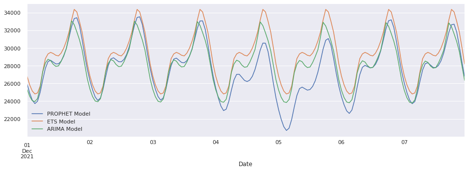

```python
plt.figure(figsize=(16,5))
pred_diciembre_local_h['PROPHET Model'].plot(figsize = (16,5), legend=True)
pred_diciembre_local_h['ETS Model'].plot(figsize = (16,5), legend=True)
pred_diciembre_local_h['ARIMA Model'].plot(figsize = (16,5), legend=True)
```

```python
pred_diciembre_local_d= predicciones_horarias_PAC.to_period('H')['2021-12':].resample('D').sum()
```

```python
pred_diciembre_local_d
```

| Date | PROPHET Model | ETS Model | ARIMA Model |
| --- | --- | --- | --- |
| 2021-12-01 | 682117.481763 | 702742.418201 | 676832.420470 |
| 2021-12-02 | 687625.265049 | 702742.418201 | 676035.861950 |
| 2021-12-03 | 682909.053945 | 702742.418201 | 675240.240537 |
| 2021-12-04 | 636478.678060 | 702742.418201 | 674445.555442 |
| 2021-12-05 | 616263.754034 | 702742.418201 | 673651.805602 |
| 2021-12-06 | 667993.732932 | 702742.418201 | 672858.989920 |
| 2021-12-07 | 672666.757922 | 702742.418201 | 672067.107296 |
| 2021-12-08 | 671109.181109 | 702742.418201 | 671276.156632 |
| 2021-12-09 | 676616.964395 | 702742.418201 | 670486.136833 |
| 2021-12-10 | 671900.753290 | 702742.418201 | 669697.046802 |
| 2021-12-11 | 625470.377405 | 702742.418201 | 668908.885445 |
| 2021-12-12 | 605255.453379 | 702742.418201 | 668121.651669 |
| 2021-12-13 | 656985.432277 | 702742.418201 | 667335.344382 |
| 2021-12-14 | 661658.457267 | 702742.418201 | 666549.962494 |
| 2021-12-15 | 660100.880454 | 702742.418201 | 665765.504917 |

```python
pred_diciembre_local_d.to_csv('predicciones_diarias_diciembre.csv', sep=',')
```